# Лабораторная работа №6.

Поиск файлов. Перенаправление ввода-вывода. Просмотр запущенных процессов.

Кузнецова С. В.

Российский университет дружбы народов, Москва, Россия

12 марта 2023

# Информация

## Докладчик

- Кузнецова София Вадимовна
- Студенческий билет - 1132227132
- НПИбд-02-22
- Российский университет дружбы народов

## Цели и задачи

Ознакомление с инструментами поиска файлов и фильтрации текстовых данных. Приобретение практических навыков: по управлению процессами (и заданиями), по проверке использования диска и обслуживанию файловых систем.

# Выполнение лабораторной работы

## Каталог /etc

Записываем в файл file.txt названия файлов, содержащихся в каталоге /etc. Дописываем в этот же файл названия файлов, содержащихся в нашем домашнем каталоге.

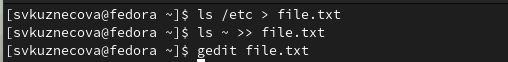

Каталог /etc

## Расширение .conf

Выводим имена всех файлов из file.txt, имеющих расширение .conf, после чего записываем их в новый текстовой файл conf.txt.

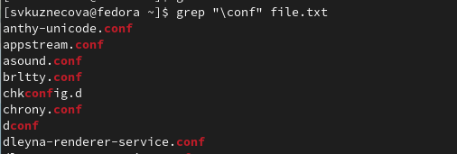

Файлы из file.txt

## Файлы начинающиеся с с

Определяем, какие файлы в нашем домашнем каталоге имеют имена, начинавшиеся с символа c? Предлгаем несколько вариантов, как это сделать.

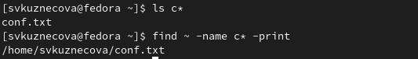

Файлы имена которых начинаются на с

## Файлы начинающиеся с h

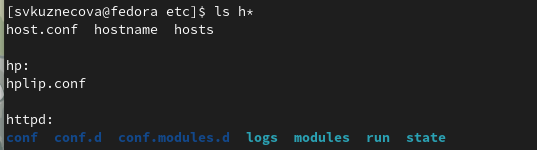

Файлы имена которых начинаются на h

## Файл logfile

Запускаем в фоновом режиме процесс, который будет записывать в файл ~/logfile файлы, имена которых начинаются с log.

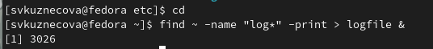

Файл ~/logfile

## Удаление logfile

Удаляем файл ~/logfile.

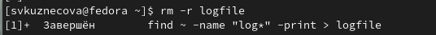

Удаление файла ~/logfile

## Редактор gedit

Запускаем из консоли в фоновом режиме редактор gedit.

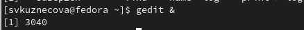

## Команда ps

Определяем идентификатор процесса gedit, используя команду ps, конвейер и фильтр grep. Определяем, как ещё можно определить идентификатор процесса.

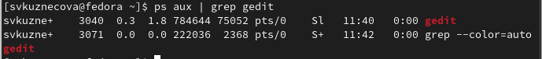

## Команда kill

Прочтём справку (man) команды kill, после чего используем её для завершения процесса gedit.

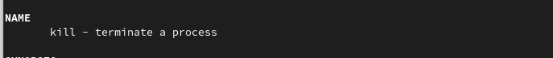

Команда kill

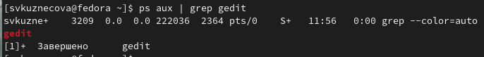

Завершение процесс gedit

## Команды df и du

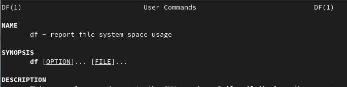

Команда df

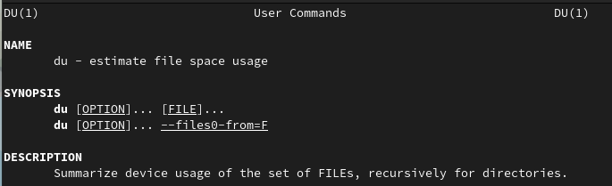

Команда du

## Команда find

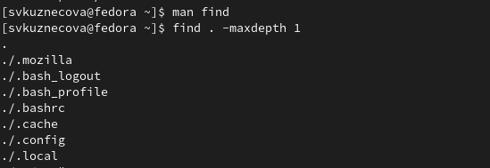

Команда find

## Вывод

Ознакомилась с инструментами поиска файлов и фильтрации текстовых данных. Приобрела практических навыков: по управлению процессами (и заданиями), по проверке использования диска и обслуживанию файловых систем.